# Section 02 - Reshape Data

Bibliotecas necessárias

```r
library (tidyverse)
library (dslabs) ##tabela gapminder
library (ggplot2)
library (dplyr)
```

Tabela utilizada até agora:

```r
data(gapminder)
head (gapminder)
```

|  | country | year | infant_mortality | life_expectancy | fertility | population | gdp | continent | region |
| --- | --- | --- | --- | --- | --- | --- | --- | --- | --- |
| 1 | Albania | 1960 | 115.40 | 62.87 | 6.19 | 1636054 | NA | Europe | Southern Europe |
| 2 | Algeria | 1960 | 148.20 | 47.50 | 7.65 | 11124892 | 13828152297 | Africa | Northern Africa |
| 3 | Angola | 1960 | 208.00 | 35.98 | 7.32 | 5270844 | NA | Africa | Middle Africa |
| 4 | Antigua and Barbuda | 1960 | NA | 62.97 | 4.43 | 54681 | NA | Americas | Caribbean |
| 5 | Argentina | 1960 | 59.87 | 65.39 | 3.11 | 20619075 | 108322326649 | Americas | South America |
| 6 | Armenia | 1960 | NA | 66.86 | 4.55 | 1867396 | NA | Asia | Western Asia |

```r
data <- gapminder %>% filter(country == "South Korea" | country == "Germany") %>% select (country, year, life_expectancy, fertility)
data
```

| country | year | life_expectancy | fertility |
| --- | --- | --- | --- |
| Germany | 1960 | 69.26 | 2.41 |
| South Korea | 1960 | 53.02 | 6.16 |
| Germany | 1961 | 69.85 | 2.44 |
| South Korea | 1961 | 53.75 | 5.99 |
| Germany | 1962 | 70.01 | 2.47 |
| South Korea | 1962 | 54.51 | 5.79 |
| Germany | 1963 | 70.10 | 2.49 |
| South Korea | 1963 | 55.27 | 5.57 |
| Germany | 1964 | 70.66 | 2.49 |
| South Korea | 1964 | 56.04 | 5.36 |

[output cut: 104 more lines]

Estes dados estão arrumados, chamados “tidy”  
Nesta seção iremos ver funcoes da biblioteca tidyr, incluida no pacote tidyverse para facilitar a arrumação dos dados

## Tidy Data

**Definição: Cada linha representa uma observação de varias variaveis diferentes**  
Inicialmente os dados não estão como na tabela acima.  
Os dados originais estão conforme o arquivo do pacote dslabs

```r
file_path <- system.file("extdata", package = "dslabs")
list.files(file_path)
```

```
[1] "2010_bigfive_regents.xls"                                "carbon_emissions.csv"
[3] "fertility-two-countries-example.csv"                     "HRlist2.txt"
[5] "life-expectancy-and-fertility-two-countries-example.csv" "murders.csv"
[7] "olive.csv"                                               "RD-Mortality-Report_2015-18-180531.pdf"
[9] "ssa-death-probability.csv"
```

```r
#1 .Path arquivo original
origin <- file.path(file_path, "fertility-two-countries-example.csv")


#2. Momear arquivo destino e setar sua path
local_filename <- "fertility.csv"
setwd("C:/Users/lfima/Documents/edx/06_Data Wrangling/Section_02_Reshape/data")
destiny <- file.path(getwd(), local_filename)
```

```r
#3. Copiar arquivos
file.copy(origin, destiny)
```

Verificando dados do arquivo original:

```r
data <- read_csv("C:/Users/lfima/Documents/edx/06_Data Wrangling/Section_02_Reshape/data/fertility.csv")
data
```

| country | 1960 | 1961 | 1962 | 1963 | 1964 | 1965 | 1966 | 1967 | 1968 | 1969 | 1970 | 1971 | 1972 | 1973 | 1974 | 1975 | 1976 | 1977 | 1978 | 1979 | 1980 | 1981 | 1982 | 1983 | 1984 | 1985 | 1986 | 1987 | 1988 | … |
| --- | --- | --- | --- | --- | --- | --- | --- | --- | --- | --- | --- | --- | --- | --- | --- | --- | --- | --- | --- | --- | --- | --- | --- | --- | --- | --- | --- | --- | --- | --- |
| Germany | 2.41 | 2.44 | 2.47 | 2.49 | 2.49 | 2.48 | 2.44 | 2.37 | 2.28 | 2.17 | 2.04 | 1.92 | 1.80 | 1.70 | 1.62 | 1.56 | 1.53 | 1.50 | 1.49 | 1.48 | 1.47 | 1.47 | 1.46 | 1.46 | 1.46 | 1.45 | 1.44 | 1.43 | 1.41 | … |
| South Korea | 6.16 | 5.99 | 5.79 | 5.57 | 5.36 | 5.16 | 4.99 | 4.85 | 4.73 | 4.62 | 4.53 | 4.41 | 4.27 | 4.09 | 3.87 | 3.62 | 3.36 | 3.11 | 2.88 | 2.69 | 2.52 | 2.38 | 2.24 | 2.11 | 1.98 | 1.86 | 1.75 | 1.67 | 1.63 | … |

**Nesta tabela, temos multiplas observações em uma mesma linha, então este dado não esta arrumado (tidy)**

## Pivot Longer

```r
data %>% select(country, '1960':'1965')
```

| country | 1960 | 1961 | 1962 | 1963 | 1964 | 1965 |
| --- | --- | --- | --- | --- | --- | --- |
| Germany | 2.41 | 2.44 | 2.47 | 2.49 | 2.49 | 2.48 |
| South Korea | 6.16 | 5.99 | 5.79 | 5.57 | 5.36 | 5.16 |

A tabela está no formato wide

Utilizando pivot_longer

```r
head (data %>% pivot_longer ('1960':'2015'))
```

| country | name | value |
| --- | --- | --- |
| Germany | 1960 | 2.41 |
| Germany | 1961 | 2.44 |
| Germany | 1962 | 2.47 |
| Germany | 1963 | 2.49 |
| Germany | 1964 | 2.49 |
| Germany | 1965 | 2.48 |

Outra maneira de utilizar pivot_longer

```r
head (data %>% pivot_longer (-country)) #country é a unica coluna que nao foi alterada
```

| country | name | value |
| --- | --- | --- |
| Germany | 1960 | 2.41 |
| Germany | 1961 | 2.44 |
| Germany | 1962 | 2.47 |
| Germany | 1963 | 2.49 |
| Germany | 1964 | 2.49 |
| Germany | 1965 | 2.48 |

```r
head (data %>% pivot_longer (-country, names_to = "year", values_to = "fertility_rate")) #country é a unica coluna que nao foi alterada
```

| country | year | fertility_rate |
| --- | --- | --- |
| Germany | 1960 | 2.41 |
| Germany | 1961 | 2.44 |
| Germany | 1962 | 2.47 |
| Germany | 1963 | 2.49 |
| Germany | 1964 | 2.49 |
| Germany | 1965 | 2.48 |

**Notar que os valores dos anos estão viraram caracteres**

```r
head (data %>% pivot_longer (-country, names_to = "year", values_to = "fertility_rate", names_transform = list(year = as.numeric)))
```

| country | year | fertility_rate |
| --- | --- | --- |
| Germany | 1960 | 2.41 |
| Germany | 1961 | 2.44 |
| Germany | 1962 | 2.47 |
| Germany | 1963 | 2.49 |
| Germany | 1964 | 2.49 |
| Germany | 1965 | 2.48 |

```r
head (data %>% pivot_longer (-country, names_to = "year", values_to = "fertility_rate") %>% mutate(year = as.numeric(year)))
```

| country | year | fertility_rate |
| --- | --- | --- |
| Germany | 1960 | 2.41 |
| Germany | 1961 | 2.44 |
| Germany | 1962 | 2.47 |
| Germany | 1963 | 2.49 |
| Germany | 1964 | 2.49 |
| Germany | 1965 | 2.48 |

Com os dados arrumados é possível plotar o gráfico conforme já realizado anteriormente:

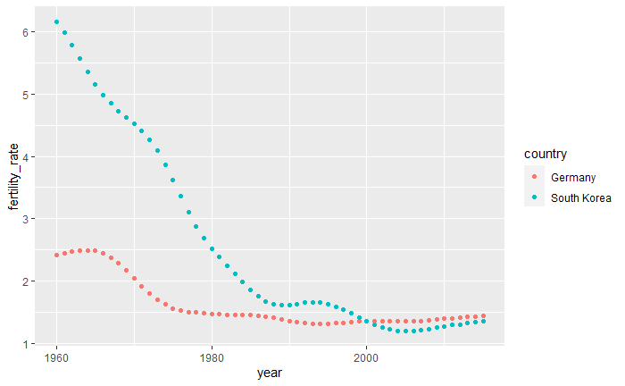

```r
library (ggplot2)

tidy_data <- data %>% pivot_longer (-country, names_to = "year", values_to = "fertility_rate") %>% mutate(year = as.numeric(year))

ggplot(tidy_data, aes(x = year, y = fertility_rate, color = country)) + geom_point()
```

## Pivot wider

Esta função transforma linhas de dados em colunas Ela é util para transformação intermerdiarias de dados

```r
new_wide_data <- tidy_data %>% pivot_wider(names_from = year, values_from = fertility_rate)
select(new_wide_data, country, `1960`:`1967`)
```

| country | 1960 | 1961 | 1962 | 1963 | 1964 | 1965 | 1966 | 1967 |
| --- | --- | --- | --- | --- | --- | --- | --- | --- |
| Germany | 2.41 | 2.44 | 2.47 | 2.49 | 2.49 | 2.48 | 2.44 | 2.37 |
| South Korea | 6.16 | 5.99 | 5.79 | 5.57 | 5.36 | 5.16 | 4.99 | 4.85 |

## Separate

Agora vamos trabalhar com um exemplo mais complexo

```r
two_variable <- read_csv("C:/Users/lfima/Documents/edx/06_Data Wrangling/Section_02_Reshape/data/two_v.csv", show_col_types = FALSE)
two_variable
```

| country | 1960_fertility | 1960_life_expectancy | 1961_fertility | 1961_life_expectancy | 1962_fertility | 1962_life_expectancy | 1963_fertility | 1963_life_expectancy | 1964_fertility | 1964_life_expectancy | 1965_fertility | 1965_life_expectancy | 1966_fertility | 1966_life_expectancy | 1967_fertility | 1967_life_expectancy | 1968_fertility | 1968_life_expectancy | 1969_fertility | 1969_life_expectancy | 1970_fertility | 1970_life_expectancy | 1971_fertility | 1971_life_expectancy | 1972_fertility | 1972_life_expectancy | 1973_fertility | 1973_life_expectancy | 1974_fertility | … |
| --- | --- | --- | --- | --- | --- | --- | --- | --- | --- | --- | --- | --- | --- | --- | --- | --- | --- | --- | --- | --- | --- | --- | --- | --- | --- | --- | --- | --- | --- | --- |
| Germany | 2.41 | 69.26 | 2.44 | 69.85 | 2.47 | 70.01 | 2.49 | 70.10 | 2.49 | 70.66 | 2.48 | 70.65 | 2.44 | 70.77 | 2.37 | 70.99 | 2.28 | 70.64 | 2.17 | 70.48 | 2.04 | 70.72 | 1.92 | 70.94 | 1.80 | 71.16 | 1.70 | 71.41 | 1.62 | … |
| South Korea | 6.16 | 53.02 | 5.99 | 53.75 | 5.79 | 54.51 | 5.57 | 55.27 | 5.36 | 56.04 | 5.16 | 56.84 | 4.99 | 57.67 | 4.85 | 58.54 | 4.73 | 59.44 | 4.62 | 60.35 | 4.53 | 61.22 | 4.41 | 62.02 | 4.27 | 62.73 | 4.09 | 63.34 | 3.87 | … |

```r
NA
```

Aqui temos: -2 variaveis: fertility e life_expectancy  
-os anos estão nos nomes das variaveis

Usando pivot_longer

```r
tidy_two <- two_variable %>% pivot_longer(-country)
head (tidy_two)
```

| country | name | value |
| --- | --- | --- |
| Germany | 1960_fertility | 2.41 |
| Germany | 1960_life_expectancy | 69.26 |
| Germany | 1961_fertility | 2.44 |
| Germany | 1961_life_expectancy | 69.85 |
| Germany | 1962_fertility | 2.47 |
| Germany | 1962_life_expectancy | 70.01 |

**Utilizando separate:**  
Separate(column_name, new_column_names, caracter_separador)

```r
tidy_two %>% separate(name, c("year", "name"), sep="_", extra="merge", convert = TRUE)
```

| country | year | name | value |
| --- | --- | --- | --- |
| Germany | 1960 | fertility | 2.41 |
| Germany | 1960 | life_expectancy | 69.26 |
| Germany | 1961 | fertility | 2.44 |
| Germany | 1961 | life_expectancy | 69.85 |
| Germany | 1962 | fertility | 2.47 |
| Germany | 1962 | life_expectancy | 70.01 |
| Germany | 1963 | fertility | 2.49 |
| Germany | 1963 | life_expectancy | 70.10 |
| Germany | 1964 | fertility | 2.49 |
| Germany | 1964 | life_expectancy | 70.66 |

[output cut: 214 more lines]

```r
tidy_two %>% separate(name, c("year", "name"), sep="_", extra="merge", convert = TRUE) %>% pivot_wider (names_from = name, values_from = value)
```

| country | year | fertility | life_expectancy |
| --- | --- | --- | --- |
| Germany | 1960 | 2.41 | 69.26 |
| Germany | 1961 | 2.44 | 69.85 |
| Germany | 1962 | 2.47 | 70.01 |
| Germany | 1963 | 2.49 | 70.10 |
| Germany | 1964 | 2.49 | 70.66 |
| Germany | 1965 | 2.48 | 70.65 |
| Germany | 1966 | 2.44 | 70.77 |
| Germany | 1967 | 2.37 | 70.99 |
| Germany | 1968 | 2.28 | 70.64 |
| Germany | 1969 | 2.17 | 70.48 |

[output cut: 102 more lines]

## Unite

Supondo a seguinte separação incorreta devido ao ’_’ em life_expectancy

```r
two_variable <- read_csv("C:/Users/lfima/Documents/edx/06_Data Wrangling/Section_02_Reshape/data/two_v.csv", show_col_types = FALSE)
two_variable <- two_variable %>% pivot_longer(-country)

head (two_variable %>%separate(name, c("year", "name_1", "name_2"),sep = "_", fill = "right", convert = TRUE))
```

| country | year | name_1 | name_2 | value |
| --- | --- | --- | --- | --- |
| Germany | 1960 | fertility | NA | 2.41 |
| Germany | 1960 | life | expectancy | 69.26 |
| Germany | 1961 | fertility | NA | 2.44 |
| Germany | 1961 | life | expectancy | 69.85 |
| Germany | 1962 | fertility | NA | 2.47 |
| Germany | 1962 | life | expectancy | 70.01 |

```r
NA
```

É possível juntar as variáveis name_1 e name_2 em uma única variável

```r
head (two_variable %>%separate(name, c("year", "name_1", "name_2"),sep = "_", fill = "right", convert = TRUE) %>%  unite(variable_name, name_1, name_2, sep="_"))
```

| country | year | variable_name | value |
| --- | --- | --- | --- |
| Germany | 1960 | fertility_NA | 2.41 |
| Germany | 1960 | life_expectancy | 69.26 |
| Germany | 1961 | fertility_NA | 2.44 |
| Germany | 1961 | life_expectancy | 69.85 |
| Germany | 1962 | fertility_NA | 2.47 |
| Germany | 1962 | life_expectancy | 70.01 |

```r
NA
```

```r
two_variable %>%separate(name, c("year", "name_1", "name_2"),sep = "_", fill = "right", convert = TRUE) %>%  unite(variable_name, name_1, name_2, sep="_") %>% pivot_wider(names_from = "variable_name", values_from = value) %>% rename(fertility = fertility_NA)
```

| country | year | fertility | life_expectancy |
| --- | --- | --- | --- |
| Germany | 1960 | 2.41 | 69.26 |
| Germany | 1961 | 2.44 | 69.85 |
| Germany | 1962 | 2.47 | 70.01 |
| Germany | 1963 | 2.49 | 70.10 |
| Germany | 1964 | 2.49 | 70.66 |
| Germany | 1965 | 2.48 | 70.65 |
| Germany | 1966 | 2.44 | 70.77 |
| Germany | 1967 | 2.37 | 70.99 |
| Germany | 1968 | 2.28 | 70.64 |
| Germany | 1969 | 2.17 | 70.48 |

[output cut: 102 more lines]

## Gather e Spread

```r
fertility <- read_csv("C:/Users/lfima/Documents/edx/06_Data Wrangling/Section_02_Reshape/data/fertility.csv")
fertility_tidy <- fertility %>% gather(key = year, value = value, '1960':'2015')
fertility_tidy
```

| country | year | value |
| --- | --- | --- |
| Germany | 1960 | 2.41 |
| South Korea | 1960 | 6.16 |
| Germany | 1961 | 2.44 |
| South Korea | 1961 | 5.99 |
| Germany | 1962 | 2.47 |
| South Korea | 1962 | 5.79 |
| Germany | 1963 | 2.49 |
| South Korea | 1963 | 5.57 |
| Germany | 1964 | 2.49 |
| South Korea | 1964 | 5.36 |

[output cut: 102 more lines]

```r
fertility_tidy %>% spread(year, value)
```

| country | 1960 | 1961 | 1962 | 1963 | 1964 | 1965 | 1966 | 1967 | 1968 | 1969 | 1970 | 1971 | 1972 | 1973 | 1974 | 1975 | 1976 | 1977 | 1978 | 1979 | 1980 | 1981 | 1982 | 1983 | 1984 | 1985 | 1986 | 1987 | 1988 | … |
| --- | --- | --- | --- | --- | --- | --- | --- | --- | --- | --- | --- | --- | --- | --- | --- | --- | --- | --- | --- | --- | --- | --- | --- | --- | --- | --- | --- | --- | --- | --- |
| Germany | 2.41 | 2.44 | 2.47 | 2.49 | 2.49 | 2.48 | 2.44 | 2.37 | 2.28 | 2.17 | 2.04 | 1.92 | 1.80 | 1.70 | 1.62 | 1.56 | 1.53 | 1.50 | 1.49 | 1.48 | 1.47 | 1.47 | 1.46 | 1.46 | 1.46 | 1.45 | 1.44 | 1.43 | 1.41 | … |
| South Korea | 6.16 | 5.99 | 5.79 | 5.57 | 5.36 | 5.16 | 4.99 | 4.85 | 4.73 | 4.62 | 4.53 | 4.41 | 4.27 | 4.09 | 3.87 | 3.62 | 3.36 | 3.11 | 2.88 | 2.69 | 2.52 | 2.38 | 2.24 | 2.11 | 1.98 | 1.86 | 1.75 | 1.67 | 1.63 | … |

## 2.1 Combining tables

Quando realizamos um trabalho de análise de dados, em geral combinam-se bases de dados diferentes para verificar e analisar correlações.

## Joins

Cada tabela possui estados diferentes agora, alguns em comum, outros não.

– Estados somente tab1 :Arkansa, Colorado  
– Estados somente tab2:Connecticut, Delaware  
– Estados em tab1 e tab2: Alabama, Alaska, Arizona, California

Reordenando pela ordem alfabetica os estados (os dados estao ordenados pelo numero de votos eleitorais)

```r
results_us_election_2016_2 <- data.frame(state = results_us_election_2016$state[order(results_us_election_2016$state)], electoral_votes = results_us_election_2016$electoral_votes[order(results_us_election_2016$state)])
results_us_election_2016_2
```

| state | electoral_votes |
| --- | --- |
| Alabama | 9 |
| Alaska | 3 |
| Arizona | 11 |
| Arkansas | 6 |
| California | 55 |
| Colorado | 9 |
| Connecticut | 7 |
| Delaware | 3 |
| District of Columbia | 3 |
| Florida | 29 |

[output cut: 41 more lines]

```r
tab1 <- slice(murders, 1:6) %>% select(state, population)
tab1
```

| state | population |
| --- | --- |
| Alabama | 4779736 |
| Alaska | 710231 |
| Arizona | 6392017 |
| Arkansas | 2915918 |
| California | 37253956 |
| Colorado | 5029196 |

```r
tab2 <- slice(results_us_election_2016_2, c(1:3, 5, 7:8))
tab2
```

| state | electoral_votes |
| --- | --- |
| Alabama | 9 |
| Alaska | 3 |
| Arizona | 11 |
| California | 55 |
| Connecticut | 7 |
| Delaware | 3 |

## Left_join

```r
left_join(tab1, tab2, by = "state")
```

| state | population | electoral_votes |
| --- | --- | --- |
| Alabama | 4779736 | 9 |
| Alaska | 710231 | 3 |
| Arizona | 6392017 | 11 |
| Arkansas | 2915918 | NA |
| California | 37253956 | 55 |
| Colorado | 5029196 | NA |

– Os valores de tab1 ficam inalterados  
– Alabama, Alaska, Arizona e California aparecem em tab2

## Right Join

```r
right_join(tab1, tab2, by = "state")
```

| state | population | electoral_votes |
| --- | --- | --- |
| Alabama | 4779736 | 9 |
| Alaska | 710231 | 3 |
| Arizona | 6392017 | 11 |
| California | 37253956 | 55 |
| Connecticut | NA | 7 |
| Delaware | NA | 3 |

– Os valores de tab2 ficam inalterados  
– Alabama, Alaska, Arizona e California aparecem em tab1

## Full Join

```r
full_join(tab1, tab2, by = "state")
```

| state | population | electoral_votes |
| --- | --- | --- |
| Alabama | 4779736 | 9 |
| Alaska | 710231 | 3 |
| Arizona | 6392017 | 11 |
| Arkansas | 2915918 | NA |
| California | 37253956 | 55 |
| Colorado | 5029196 | NA |
| Connecticut | NA | 7 |
| Delaware | NA | 3 |

– Junta todos os estados em uma mesma tabela, quando o valor não existir, adiciona NA

## Inner join

```r
inner_join(tab1, tab2, by = "state")
```

| state | population | electoral_votes |
| --- | --- | --- |
| Alabama | 4779736 | 9 |
| Alaska | 710231 | 3 |
| Arizona | 6392017 | 11 |
| California | 37253956 | 55 |

Pega somente os valores que estão em tab1 e tab2

## Semi_join

```r
semi_join(tab1, tab2, by = "state")
```

| state | population |
| --- | --- |
| Alabama | 4779736 |
| Alaska | 710231 |
| Arizona | 6392017 |
| California | 37253956 |

– Não combina tabelas  
– Mantem as colunas de tab1  
– Somente os valores que estão em tab1 e tab2 são mantidos

## Anti_join

```r
anti_join(tab1, tab2, by="state")
```

| state | population |
| --- | --- |
| Arkansas | 2915918 |
| Colorado | 5029196 |

– Não combina tabelas  
– Mantem as colunas de tab1  
– Somente os valores que estão em tab1 são mantidos

## Binding

– Diferente das funcoes de join que juntam as tabelas através de uma coluna em comum (states) nos exemplos, as funcoes de binding somente juntam as tabelas

### bind_cols

```r
data("murders")
data ("results_us_election_2016")
tab <- left_join(murders, results_us_election_2016_2, by = "state")
head(tab)
```

|  | state | abb | region | population | total | electoral_votes |
| --- | --- | --- | --- | --- | --- | --- |
| 1 | Alabama | AL | South | 4779736 | 135 | 9 |
| 2 | Alaska | AK | West | 710231 | 19 | 3 |
| 3 | Arizona | AZ | West | 6392017 | 232 | 11 |
| 4 | Arkansas | AR | South | 2915918 | 93 | 6 |
| 5 | California | CA | West | 37253956 | 1257 | 55 |
| 6 | Colorado | CO | West | 5029196 | 65 | 9 |

```r
tab1 <- tab[,c(1:2,4) ]
tab1 <- slice(tab1, 1:3)
tab1
```

| state | abb | population |
| --- | --- | --- |
| Alabama | AL | 4779736 |
| Alaska | AK | 710231 |
| Arizona | AZ | 6392017 |

```r
tab2 <- tab[,5:6]
tab2 <- slice(tab2, 4:6)
tab2
```

| total | electoral_votes |
| --- | --- |
| 93 | 6 |
| 1257 | 55 |
| 65 | 9 |

```r
new_tab <- bind_cols(tab1, tab2)
new_tab
```

| state | abb | population | total | electoral_votes |
| --- | --- | --- | --- | --- |
| Alabama | AL | 4779736 | 93 | 6 |
| Alaska | AK | 710231 | 1257 | 55 |
| Arizona | AZ | 6392017 | 65 | 9 |

– Deve ter o mesmo numero de linhas – As colunas somente devem são colocadas lado a lado

### bind_rows

```r
new_tab1 <- slice(new_tab, 1)
new_tab1
```

| state | abb | population | total | electoral_votes |
| --- | --- | --- | --- | --- |
| Alabama | AL | 4779736 | 93 | 6 |

```r
new_tab2 <- slice(new_tab, 3)
new_tab2
```

| state | abb | population | total | electoral_votes |
| --- | --- | --- | --- | --- |
| Arizona | AZ | 6392017 | 65 | 9 |

```r
NA
```

```r
bind_rows(new_tab2, new_tab1)
```

| state | abb | population | total | electoral_votes |
| --- | --- | --- | --- | --- |
| Arizona | AZ | 6392017 | 65 | 9 |
| Alabama | AL | 4779736 | 93 | 6 |

– Notar que a ordem se altera

## Set Operators

**Funcionam por linhas**  
**Union, Intersect**

# Dados

### Tab1

```r
tab1 <- slice(murders, 1:6) %>% select(state, population)
tab1
```

| state | population |
| --- | --- |
| Alabama | 4779736 |
| Alaska | 710231 |
| Arizona | 6392017 |
| Arkansas | 2915918 |
| California | 37253956 |
| Colorado | 5029196 |

### Tab2

```r
tab2 <- slice(murders, 5:9) %>% select(state, population)
tab2
```

| state | population |
| --- | --- |
| California | 37253956 |
| Colorado | 5029196 |
| Connecticut | 3574097 |
| Delaware | 897934 |
| District of Columbia | 601723 |

**Estados em comum: California, Colorado**  
**Estados somente em tab1: Alabama, Alaska, Arizona, Arkansas**  
**Estados somente em tab2: Connecticut, Delaware, District of Columbia**

### Union

```r
union(tab1, tab2)
```

| state | population |
| --- | --- |
| Alabama | 4779736 |
| Alaska | 710231 |
| Arizona | 6392017 |
| Arkansas | 2915918 |
| California | 37253956 |
| Colorado | 5029196 |
| Connecticut | 3574097 |
| Delaware | 897934 |
| District of Columbia | 601723 |

### Intersect

```r
intersect(tab1, tab2)
```

| state | population |
| --- | --- |
| California | 37253956 |
| Colorado | 5029196 |

### Setdiff

```r
setdiff(tab1, tab2)
```

| state | population |
| --- | --- |
| Alabama | 4779736 |
| Alaska | 710231 |
| Arizona | 6392017 |
| Arkansas | 2915918 |

– Mostra tab1 - tab2, ou seja, itens exclusivos de tab1

```r
setdiff(tab2, tab1)
```

| state | population |
| --- | --- |
| Connecticut | 3574097 |
| Delaware | 897934 |
| District of Columbia | 601723 |

– Mostra tab2 - tab1, ou seja, itens exclusivos de tab2

### setequal()

```r
setequal(tab1, tab2)
```

```
[1] FALSE
```

```r
setequal(tab1[6:5,], tab2[1:2,])
```

```
[1] TRUE
```

```r
#tab1[6:5,]
#tab2[1:2,]
```

– Verifica se os conjuntos são identicos não importando a ordem

## Web Scraping

O conjunto de dados da tabela “murders” veio da Wikipedia, vamos verificar como analisar o código fonte para obter os dados que queremos

```r
library(rvest)
url <- "https://en.wikipedia.org/wiki/Murder_in_the_United_States_by_state"
h <- read_html(url)
class(h)
```

```
[1] "xml_document" "xml_node"
```

```r
h
```

```
{html_document}
<html class="client-nojs" lang="en" dir="ltr">
[1] <head>\n<meta http-equiv="Content-Type" content="text/html; charset=UTF-8">\n<meta charset="UTF-8">\n<title>Gun v ...
[2] <body class="mediawiki ltr sitedir-ltr mw-hide-empty-elt ns-0 ns-subject mw-editable page-Gun_violence_in_the_Uni ...
```

Obs. Não é possível visualizar o código fonte dessa forma, imprimindo h, h[1] etc

Analisando o código fonte da página,

```r
tabs <- h %>% html_nodes("table")
tab <- tabs[[2]]
tab
```

```
{html_node}
<table class="wikitable sortable">
[1] <tbody>\n<tr>\n<th data-sort-type="text">State\n</th>\n<th data-sort-type="number">Population<br><small>(total in ...
```

**Cada elemento retornado em tabs é um conjunto de nodes (pode ter somente 1 elemento)**  
**Pega-se o primeiro elemento do conjunto de nodes 2 usando-se [[2]]**  
**Para transformar em tabela é ideal utilizar somente 1 node**

```r
class (tabs)
```

```
[1] "xml_nodeset"
```

```r
class (tabs[2])
```

```
[1] "xml_nodeset"
```

```r
class (tabs[[2]])
```

```
[1] "xml_node"
```

```r
tab <- html_table(tab)
#class(tab)
```

```r
tab <- tab %>% setNames(c("state", "population", "total", "murders", "gun_murders", "gun_ownership", "total_rate", "murder_rate", "gun_murder_rate"))
head(tab)
```

| state | population | total | murders | gun_murders | gun_ownership | total_rate | murder_rate | gun_murder_rate |
| --- | --- | --- | --- | --- | --- | --- | --- | --- |
| Alabama | 4,853,875 | 348 | —[a] | —[a] | 48.9 | 7.2 | — [a] | — [a] |
| Alaska | 737,709 | 59 | 57 | 39 | 61.7 | 8.0 | 7.7 | 5.3 |
| Arizona | 6,817,565 | 306 | 278 | 171 | 32.3 | 4.5 | 4.1 | 2.5 |
| Arkansas | 2,977,853 | 181 | 164 | 110 | 57.9 | 6.1 | 5.5 | 3.7 |
| California | 38,993,940 | 1,861 | 1,861 | 1,275 | 20.1 | 4.8 | 4.8 | 3.3 |
| Colorado | 5,448,819 | 176 | 176 | 115 | 34.3 | 3.2 | 3.2 | 2.1 |